# Analysis of Pre and Post Intervention data in Different Communities

12/21/2020

## Data Introduction

- SOF is a tool for screen **Frailty Status** with total 3 items, the score range from 0-3, higher score means more frailty
- KCL is another tool for screen **Risk of Frailty** with total 25 items, he score range from 0-25, higher score means more frailty
- The dataset also included demographic data such as Age, Gender, Education, Living Status…etc
- The measurement between pre and post test is **Functional Fittness**, contains 6 components

## Data Structure

```r
dta<- read_excel("project.xlsx", sheet=1)
dim(dta)
```

```
## [1] 740  56
```

```r
names(dta)
```

```
##  [1] "Year"             "Area"             "Class"            "ID"
##  [5] "Age"              "Gender"           "Education"        "Living"
##  [9] "everfall"         "activity"         "Rate"             "ever_participate"
## [13] "Time"             "SOF_1"            "SOF_2"            "SOF_3"
## [17] "SOF_S"            "SOF_def"          "K_Q1"             "K_Q2"
## [21] "K_Q3"             "K_Q4"             "K_Q5"             "K_Q6"
## [25] "K_Q7"             "K_Q8"             "K_Q9"             "K_Q10"
## [29] "K_Q11"            "K_Q12"            "K_Q13"            "K_Q14"
## [33] "K_Q15"            "K_Q16"            "K_Q17"            "K_Q18"
## [37] "K_Q19"            "K_Q20"            "K_Q21"            "K_Q22"
## [41] "K_Q23"            "K_Q24"            "K_Q25"            "KCLs"
## [45] "KCL_def"          "Height"           "Weight"           "BMI"
## [49] "WC"               "HIPC"             "STAND_30sec"      "Grip"
## [53] "UpReach"          "DownReach"        "STEP_2min"        "WALK"
```

```r
# data wrangling
dta <- dta %>% mutate(
        KCL_def=factor(KCL_def, levels=0:1, labels=c("No_risk", "At_Risk")),
        activity=factor(activity, levels=0:2, labels=c("Low", "Medium", "High")),
        SOF_def=factor(SOF_def, levels = c("Robust", "Pre-frailty", "Frailty")),
        Gender=factor(ifelse(Gender=="男", "Male", "Female")))
```

```r
dta$Rate<-as.numeric(dta$Rate)
dta$WC<-as.numeric(dta$WC)
dta$HIPC<-as.numeric(dta$HIPC)
dta$STAND_30sec<-as.numeric(dta$STAND_30sec)
dta$Grip=as.numeric(dta$Grip)
dta$UpReach=as.numeric(dta$UpReach)
dta$DownReach=as.numeric(dta$DownReach)
dta$STEP_2min=as.numeric(dta$STEP_2min)
dta$WALK=as.numeric(dta$WALK)
```

## Descriptive statistics

## Class by Time

```r
addmargins(with(dta, table(Class, Time)))
```

```
##      Time
## Class Baseline Intervention Sum
##   B         17           13  30
##   C         27           24  51
##   D         49           46  95
##   E         28           28  56
##   F         36           36  72
##   G         37           37  74
##   H         48           48  96
##   I         36           36  72
##   J         40           34  74
##   K         44           38  82
##   L         38            0  38
##   Sum      400          340 740
```

**Class L only got Baseline Data**

```r
dta<-subset(dta, Class!="L")
```

Delete Class L data

## Gender by Time

```r
addmargins((with(dta, table(Gender, Time))))
```

```
##         Time
## Gender   Baseline Intervention Sum
##   Female      268          254 522
##   Male         94           86 180
##   Sum         362          340 702
```

```r
addmargins(with(dta, table(Education, Class)))
```

```
##          Class
## Education   B   C   D   E   F   G   H   I   J   K Sum
##    不識字   9  13  11  18  25  14   0  10  12  14 126
##    大學     0   0  16   0   0  14  28  18  18  17 111
##    高中職   5   2  18   2   9   6  22  12  27  15 118
##    國小    15  32  28  32  37  22   8  12  12  26 224
##    國中     1   4  20   0   1  18  34  16   4  10 108
##    缺       0   0   0   4   0   0   0   0   0   0   4
##    研究所   0   0   2   0   0   0   4   4   1   0  11
##    Sum     30  51  95  56  72  74  96  72  74  82 702
```

## Frailty by Time

```r
addmargins(with(dta, table(SOF_def, Time)))
```

```
##              Time
## SOF_def       Baseline Intervention Sum
##   Robust           272          238 510
##   Pre-frailty       70           58 128
##   Frailty           18            9  27
##   Sum              360          305 665
```

```r
a<-as.data.frame(with(dta, ftable(SOF_def,Time)))
summary(xtabs(Freq~., a))  #Chisq
```

```
## Call: xtabs(formula = Freq ~ ., data = a)
## Number of cases in table: 665
## Number of factors: 2
## Test for independence of all factors:
##  Chisq = 1.8555, df = 2, p-value = 0.3954
```

## More Informations

```r
summarySE(dta, measurevar="Age", groupvars=c("Gender", "SOF_def","Time"), na.rm=TRUE)
```

```
##    Gender     SOF_def         Time   N      Age        sd        se        ci
## 1  Female      Robust     Baseline 198 72.85859  7.726295 0.5490839  1.082837
## 2  Female      Robust Intervention 173 73.92486  7.328672 0.5571886  1.099808
## 3  Female Pre-frailty     Baseline  54 75.07407  8.377535 1.1400381  2.286627
## 4  Female Pre-frailty Intervention  44 74.79545  8.679244 1.3084453  2.638731
## 5  Female     Frailty     Baseline  14 75.35714 10.322545 2.7588163  5.960060
## 6  Female     Frailty Intervention   8 73.37500 11.070392 3.9139745  9.255079
## 7  Female        <NA>     Baseline   2 73.00000  1.414214 1.0000000 12.706205
## 8  Female        <NA> Intervention  29 67.20690  6.061467 1.1255861  2.305659
## 9    Male      Robust     Baseline  74 75.01351  6.829616 0.7939267  1.582294
## 10   Male      Robust Intervention  65 75.78462  6.936075 0.8603142  1.718675
## 11   Male Pre-frailty     Baseline  16 78.50000 10.250203 2.5625508  5.461948
## 12   Male Pre-frailty Intervention  14 75.35714  9.739745 2.6030564  5.623561
## 13   Male     Frailty     Baseline   4 74.75000  6.238322 3.1191612  9.926563
## 14   Male     Frailty Intervention   1 76.00000        NA        NA        NA
## 15   Male        <NA> Intervention   6 71.50000  8.871302 3.6216939  9.309861
```

```r
summarySE(dta, measurevar="Grip", groupvars=c("SOF_def","Time"), na.rm=TRUE)
```

```
##       SOF_def         Time   N     Grip       sd        se         ci
## 1      Robust     Baseline 266 25.36429 8.106292 0.4970286  0.9786276
## 2      Robust Intervention 194 25.19691 7.594728 0.5452697  1.0754526
## 3 Pre-frailty     Baseline  70 23.52000 6.387411 0.7634416  1.5230243
## 4 Pre-frailty Intervention  47 22.30851 6.292433 0.9178456  1.8475274
## 5     Frailty     Baseline  18 23.64444 7.582505 1.7872135  3.7706909
## 6     Frailty Intervention   7 22.25714 8.421175 3.1829050  7.7882880
## 7        <NA>     Baseline   2 16.25000 1.767767 1.2500000 15.8827559
## 8        <NA> Intervention   3 23.30000 7.483983 4.3208795 18.5912441
```

## Data Visulization

## Take Grip for Example

**Overall** difference between Before and After Intervention

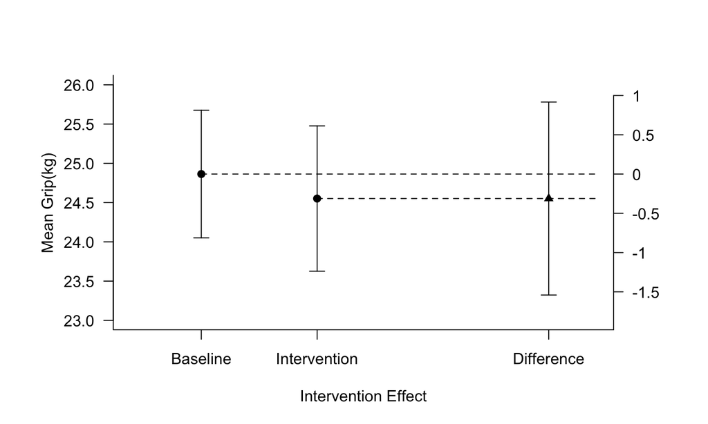

```r
diffPlot(Grip~Time, data=dta, ylim = c(23, 26),
         xlab="Intervention Effect", ylab="Mean Grip(kg)")
```

## Relationships between Age, Frailty and Grip strength

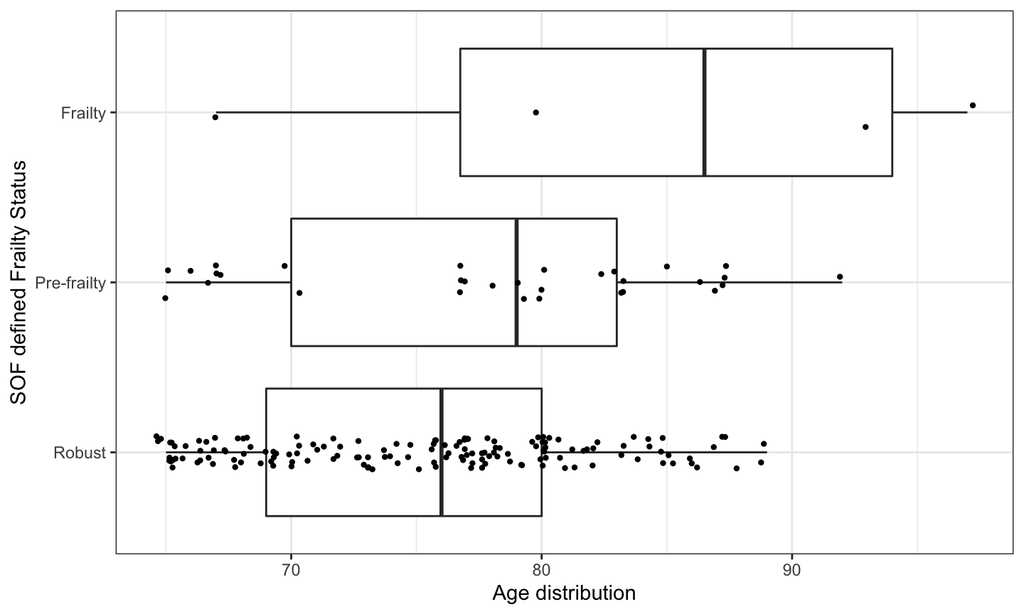

## Age by Grip

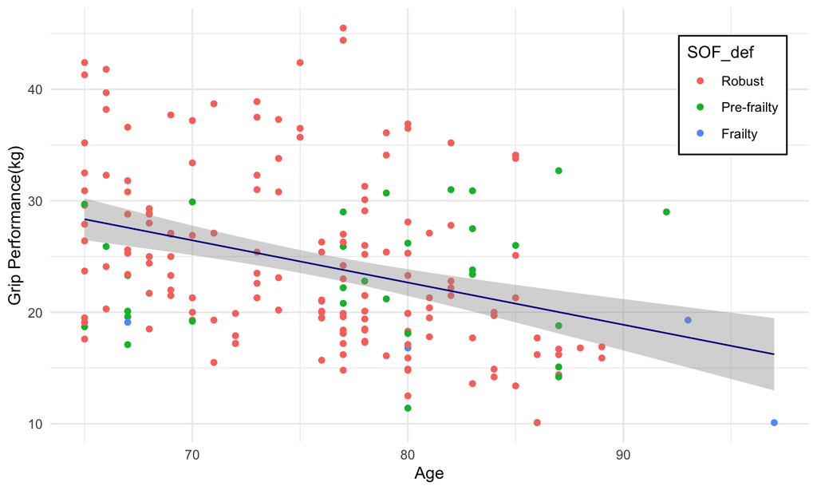

## By Gender

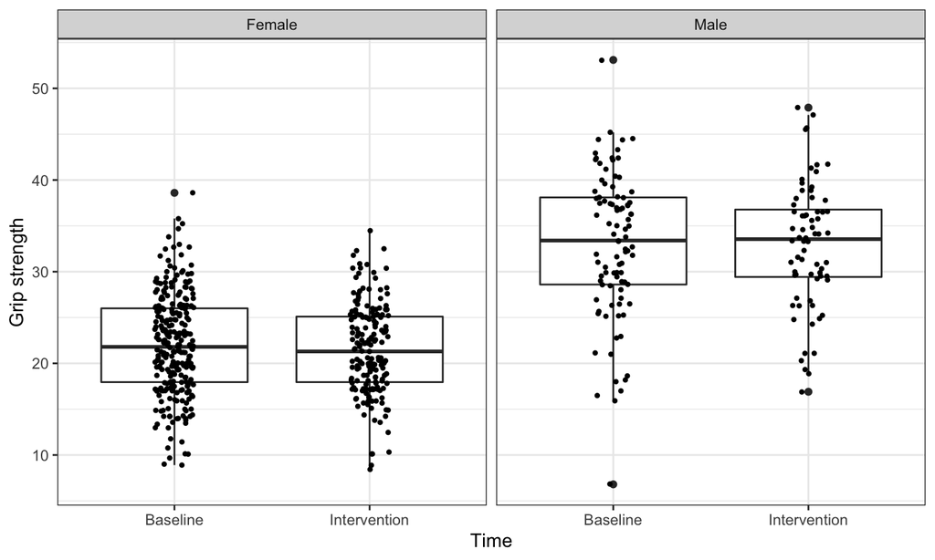

## Different Baseline of Grip gains by Different Frailty Status

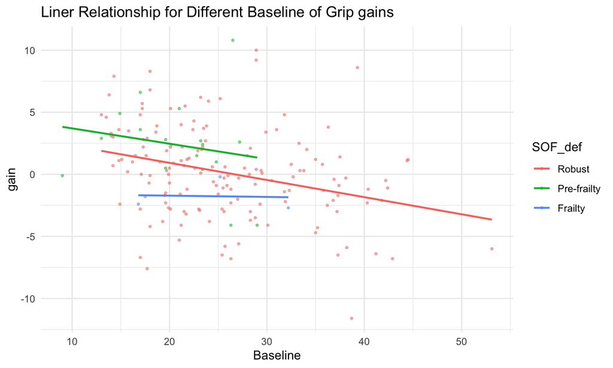

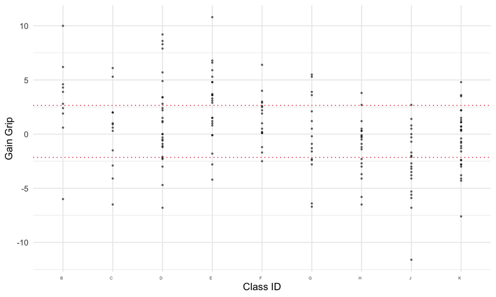

## Class gain grip means and CIs

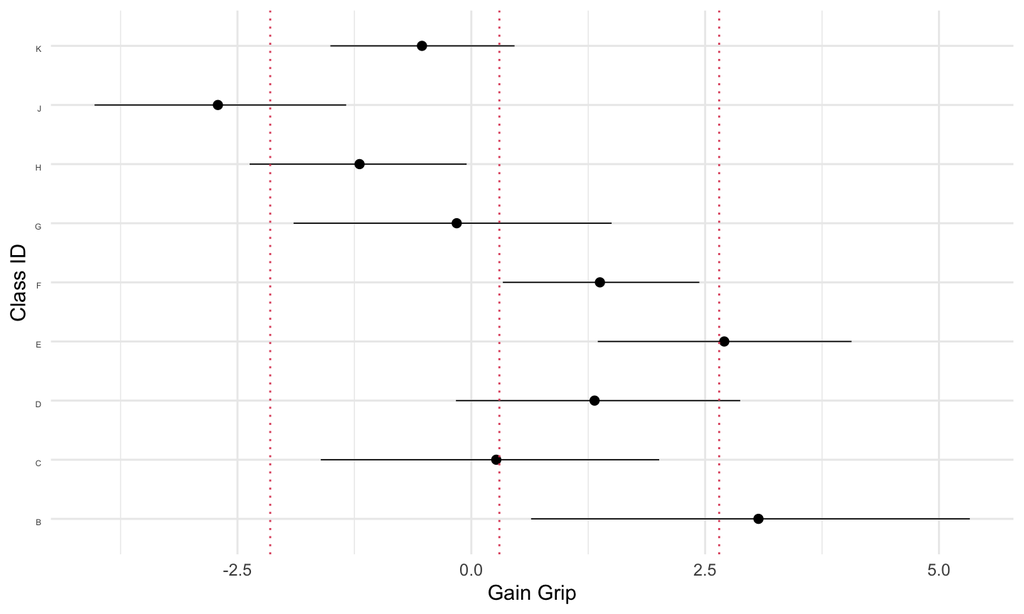

## Different Class of Grip gains

```r
sdta <- dtagW %>% group_by(Class) %>% na.omit() %>%
  dplyr::summarise(gain_ave=mean(gain),
                   gain_sd2=var(gain),
                   n=n())
m_g<-lme4::lmer(gain~(1|Class), data=dtagW)
sdta<-data.frame(Class=row.names(coef(m_g)$Class),
                 yhat=coef(m_g)$Class[,1]) %>%
  inner_join(., sdta, by="Class") %>% select(-2) %>%
  data.frame()
arrange(sdta, -gain_ave)
```

```
##   Class   gain_ave  gain_sd2  n
## 1     B  3.0700000 16.957889 10
## 2     E  2.7043478 11.456798 23
## 3     F  1.3750000  5.164667 16
## 4     D  1.3178571 16.305966 28
## 5     C  0.2666667 13.129697 12
## 6     G -0.1562500 13.470625 16
## 7     K -0.5275862  7.430640 29
## 8     H -1.1950000  6.716289 20
## 9     J -2.7095238 10.646905 21
```

- Improvement on Grip: B>E>F>D>C>G>K>H>J

## By Gender and Class

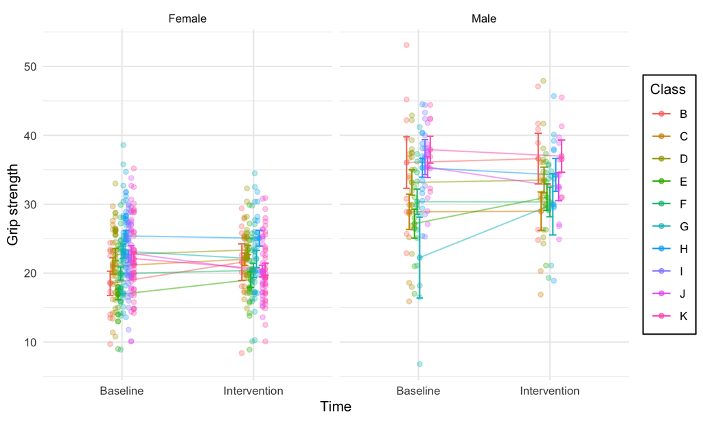

## By Time and Frailty Status

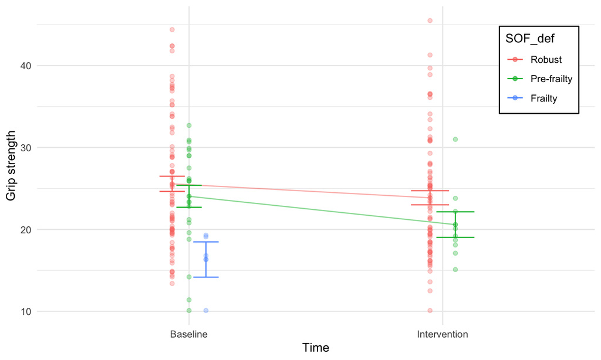

## Individuals differences

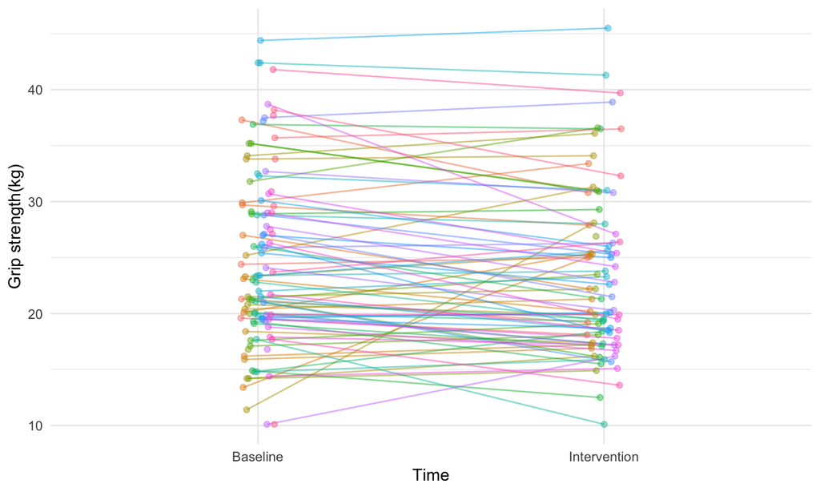

## Analysis

## Random Class Intercept

```r
m0<-lme4::lmer(gain~Class+(1|Class), data=dtagW)
sjPlot::tab_model(m0, show.r2=F)
```

|  | gain |  |  |
| --- | --- | --- | --- |
| Predictors | Estimates | CI | p |
| (Intercept) | 3.07 | -0.92 – 7.06 | 0.132 |
| Class [C] | -2.80 | -8.39 – 2.78 | 0.325 |
| Class [D] | -1.75 | -7.16 – 3.65 | 0.525 |
| Class [E] | -0.37 | -5.80 – 5.07 | 0.895 |
| Class [F] | -1.70 | -7.20 – 3.81 | 0.546 |
| Class [G] | -3.23 | -8.73 – 2.28 | 0.251 |
| Class [H] | -4.27 | -9.72 – 1.19 | 0.126 |
| Class [J] | -5.78 | -11.23 – -0.33 | **0.038** |
| Class [K] | -3.60 | -9.00 – 1.80 | 0.192 |
| Random Effects |  |  |  |
| σ<sup>2</sup> | 10.95 |  |  |
| τ<sub>00</sub> <sub>Class</sub> | 3.06 |  |  |
| ICC | 0.22 |  |  |
| N <sub>Class</sub> | 9 |  |  |
| Observations | 175 |  |  |

## Models Comparison

```r
m1<-lmer(gain~Baseline+Class+(1|Class), data=dtagW)
m2<-lmer(gain~Baseline+Gender+Class+(1|Class), data=dtagW)
m3<-lmer(gain~Baseline+Gender+Age+Class+(1|Class), data=dtagW)
m4<-lmer(gain~Baseline+Gender*Age+Class+(1|Class), data=dtagW)
anova(m0, m1, m2, m3, m4)
```

```
## Data: dtagW
## Models:
## m0: gain ~ Class + (1 | Class)
## m1: gain ~ Baseline + Class + (1 | Class)
## m2: gain ~ Baseline + Gender + Class + (1 | Class)
## m3: gain ~ Baseline + Gender + Age + Class + (1 | Class)
## m4: gain ~ Baseline + Gender * Age + Class + (1 | Class)
##    npar    AIC    BIC  logLik deviance   Chisq Df Pr(>Chisq)
## m0   11 928.20 963.02 -453.10   906.20
## m1   12 919.21 957.18 -447.60   895.21 10.9971  1  0.0009126 ***
## m2   13 910.54 951.68 -442.27   884.54 10.6664  1  0.0010910 **
## m3   14 908.12 952.42 -440.06   880.12  4.4236  1  0.0354457 *
## m4   15 909.77 957.25 -439.89   879.77  0.3421  1  0.5586472
## ---
## Signif. codes:  0 '***' 0.001 '**' 0.01 '*' 0.05 '.' 0.1 ' ' 1
```

```r
tab_model(m2, m3)
```

|  | gain |  |  | gain |  |  |
| --- | --- | --- | --- | --- | --- | --- |
| Predictors | Estimates | CI | p | Estimates | CI | p |
| (Intercept) | 7.45 | 3.23 – 11.66 | **0.001** | 13.84 | 5.81 – 21.88 | **0.001** |
| Baseline | -0.22 | -0.31 – -0.12 | **<0.001** | -0.25 | -0.35 – -0.16 | **<0.001** |
| Gender [Male] | 2.53 | 0.99 – 4.08 | **0.001** | 3.10 | 1.47 – 4.72 | **<0.001** |
| Class [C] | -2.55 | -7.83 – 2.74 | 0.344 | -2.27 | -9.08 – 4.54 | 0.514 |
| Class [D] | -1.47 | -6.58 – 3.64 | 0.573 | -1.46 | -8.14 – 5.22 | 0.668 |
| Class [E] | -1.08 | -6.23 – 4.07 | 0.680 | -0.93 | -7.64 – 5.77 | 0.785 |
| Class [F] | -1.66 | -6.87 – 3.55 | 0.531 | -1.51 | -8.26 – 5.24 | 0.661 |
| Class [G] | -2.52 | -7.75 – 2.71 | 0.346 | -2.72 | -9.49 – 4.04 | 0.430 |
| Class [H] | -3.28 | -8.46 – 1.90 | 0.214 | -3.08 | -9.81 – 3.65 | 0.369 |
| Class [J] | -5.13 | -10.29 – 0.03 | 0.051 | -5.13 | -11.84 – 1.59 | 0.134 |
| Class [K] | -3.13 | -8.24 – 1.99 | 0.231 | -2.96 | -9.64 – 3.72 | 0.386 |
| Age |  |  |  | -0.08 | -0.15 – -0.00 | **0.041** |
| Random Effects |  |  |  |  |  |  |
| σ<sup>2</sup> | 9.79 |  |  | 9.61 |  |  |
| τ<sub>00</sub> | 2.73 <sub>Class</sub> |  |  | 5.15 <sub>Class</sub> |  |  |
| ICC | 0.22 |  |  | 0.35 |  |  |
| N | 9 <sub>Class</sub> |  |  | 9 <sub>Class</sub> |  |  |
| Observations | 175 |  |  | 175 |  |  |
| Marginal R<sup>2</sup> / Conditional R<sup>2</sup> | 0.250 / 0.414 |  |  | 0.230 / 0.499 |  |  |

## Age effect with Random Slope

```r
m5<-update(m3,.~(Age|Class))
m5a<-update(m3, .~(Baseline+Age|Class))
anova(m3, m5, m5a)
```

```
## Data: dtagW
## Models:
## m5: gain ~ (Age | Class)
## m5a: gain ~ (Baseline + Age | Class)
## m3: gain ~ Baseline + Gender + Age + Class + (1 | Class)
##     npar    AIC    BIC  logLik deviance   Chisq Df Pr(>Chisq)
## m5     5 939.38 955.20 -464.69   929.38
## m5a    8 937.63 962.95 -460.81   921.63  7.7501  3    0.05147 .
## m3    14 908.12 952.42 -440.06   880.12 41.5134  6  2.294e-07 ***
## ---
## Signif. codes:  0 '***' 0.001 '**' 0.01 '*' 0.05 '.' 0.1 ' ' 1
```

After model comparing, it seems NO need to consider random slope

```r
tab_model(m3)
```

|  | gain |  |  |
| --- | --- | --- | --- |
| Predictors | Estimates | CI | p |
| (Intercept) | 13.84 | 5.81 – 21.88 | **0.001** |
| Baseline | -0.25 | -0.35 – -0.16 | **<0.001** |
| Gender [Male] | 3.10 | 1.47 – 4.72 | **<0.001** |
| Age | -0.08 | -0.15 – -0.00 | **0.041** |
| Class [C] | -2.27 | -9.08 – 4.54 | 0.514 |
| Class [D] | -1.46 | -8.14 – 5.22 | 0.668 |
| Class [E] | -0.93 | -7.64 – 5.77 | 0.785 |
| Class [F] | -1.51 | -8.26 – 5.24 | 0.661 |
| Class [G] | -2.72 | -9.49 – 4.04 | 0.430 |
| Class [H] | -3.08 | -9.81 – 3.65 | 0.369 |
| Class [J] | -5.13 | -11.84 – 1.59 | 0.134 |
| Class [K] | -2.96 | -9.64 – 3.72 | 0.386 |
| Random Effects |  |  |  |
| σ<sup>2</sup> | 9.61 |  |  |
| τ<sub>00</sub> <sub>Class</sub> | 5.15 |  |  |
| ICC | 0.35 |  |  |
| N <sub>Class</sub> | 9 |  |  |
| Observations | 175 |  |  |
| Marginal R<sup>2</sup> / Conditional R<sup>2</sup> | 0.230 / 0.499 |  |  |

## Interpretation

- The estimate mean of gain Grip for all **Class** is 13.84 with as variance of 5.15
- The estimate mean of gain Grip for all **Case** is 13.84 with as variance of 5.15+9.61=14.76
- On average, there is a drop of 0.25 kg on gain Grip from an increase of one kg in Baseline average Grip performance
- Male Grip performance averagely higher than Female, about 3.1kg
- And Age, there is a drop of 0.08kg on one year growth
- After adjusting for school difference in Baseline Grip, correlation between gain scores among case attending the same class is 0.35

## Residuals

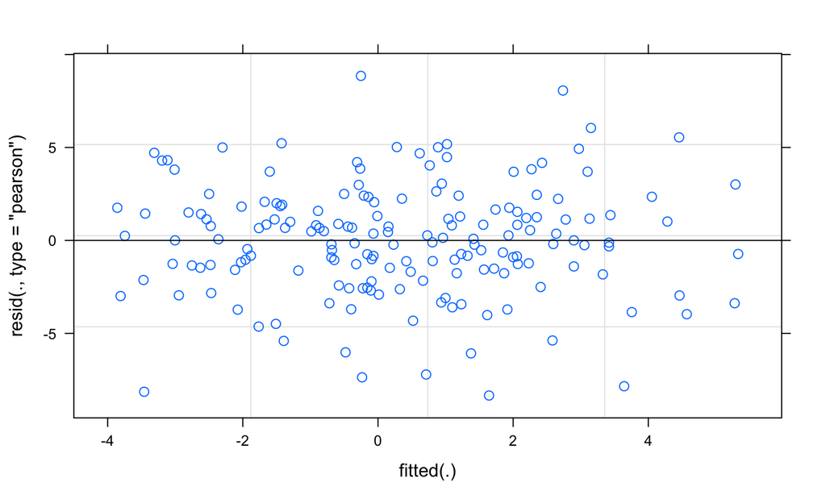

```r
plot(m3)
```

## Normality

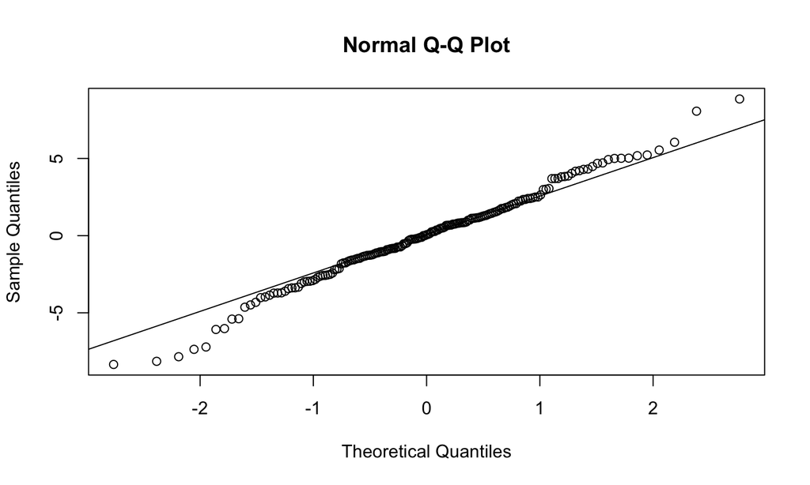

```r
qqnorm(resid(m3))
qqline(resid(m3))
```

## Generalized Linear Models

At Frailty Risk?

## Descriptive statistics

```r
dtak<-dta %>% select(Class, ID,KCL_def, Age, Gender, Time, Education, Living)
dtaf <- with(dtak, ftable(Class, Time, KCL_def)) %>% as.data.frame
addmargins(with(dtak, table(Time, KCL_def)))
```

```
##               KCL_def
## Time           No_risk At_Risk Sum
##   Baseline         321      32 353
##   Intervention     269      11 280
##   Sum              590      43 633
```

```r
addmargins(with(dtak, table(Gender, KCL_def)))
```

```
##         KCL_def
## Gender   No_risk At_Risk Sum
##   Female     432      33 465
##   Male       158      10 168
##   Sum        590      43 633
```

## Add Variables

```r
dtakW <-dtaf %>% spread(KCL_def, Freq) %>%
  inner_join(., dtak, by=c("Time", "Class")) %>%
  mutate(Total=No_risk+At_Risk)
```

```r
g0<-glm(cbind(At_Risk, No_risk)~Time+Gender*Age+Education+Living, data=dtakW,
        family=binomial(link =logit ))
g1<-glm(cbind(At_Risk, No_risk)~Time+Gender*Age+Education, data=dtakW,
        family=binomial(link =logit ))
anova(g0, g1, test="Chisq")
```

```
## Analysis of Deviance Table
##
## Model 1: cbind(At_Risk, No_risk) ~ Time + Gender * Age + Education + Living
## Model 2: cbind(At_Risk, No_risk) ~ Time + Gender * Age + Education
##   Resid. Df Resid. Dev Df Deviance Pr(>Chi)
## 1       690     608.25
## 2       691     608.57 -1 -0.32146   0.5707
```

```r
tab_model(g1)
```

|  | cbind(At_Risk, No_risk) |  |  |
| --- | --- | --- | --- |
| Predictors | Odds Ratios | CI | p |
| (Intercept) | 0.04 | 0.02 – 0.09 | **<0.001** |
| Time [Intervention] | 0.36 | 0.32 – 0.41 | **<0.001** |
| Gender [Male] | 2.54 | 0.74 – 8.65 | 0.137 |
| Age | 1.01 | 1.00 – 1.02 | **0.007** |
| Education [大學] | 0.69 | 0.56 – 0.84 | **<0.001** |
| Education [高中職] | 0.85 | 0.70 – 1.03 | 0.089 |
| Education [國小] | 1.03 | 0.88 – 1.21 | 0.717 |
| Education [國中] | 0.67 | 0.55 – 0.82 | **<0.001** |
| Education [缺] | 1.76 | 0.89 – 3.19 | 0.078 |
| Education [研究所] | 0.58 | 0.34 – 0.93 | **0.032** |
| Gender [Male] * Age | 0.99 | 0.97 – 1.01 | 0.212 |
| Observations | 702 |  |  |
| R<sup>2</sup> Tjur | 0.000 |  |  |

## Goodness of fit

```r
(g1$null.deviance - g1$deviance)/g1$null.deviance
```

```
## [1] 0.373979
```

```r
1 - pchisq(g1$deviance, g1$df.residual)
```

```
## [1] 0.9891091
```

## Residual

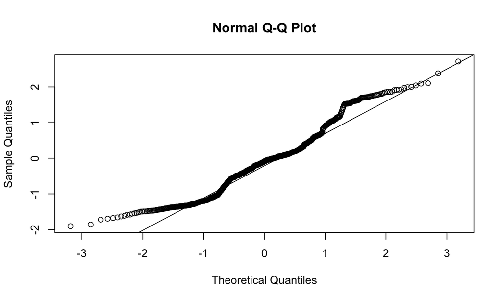

```r
qqnorm(resid(g1))
qqline(resid(g1))
```

## Interpretation

- The Odds of after intervention being at frailty risk is between 0.32-0.41
- The Odds of Higher Education(大學、研究所) at frailty risk is respectively between 0.56-0.84 and 0.34-0.93

## Limitation

```
##              Time
## SOF_def       Baseline Intervention Sum
##   Robust           272          238 510
##   Pre-frailty       70           58 128
##   Frailty           18            9  27
##   Sum              360          305 665
```

- The dropout rate roughly calculated is (360-305)/360=15.2%
- The SOF_def group sample size is significantly different, hard to infer the effects on different Frailty Status, which is one of major research question.